# STS 112: Notebook 4

Notice that there is no output to this code, since we created a variable (`agehist`) and assigned it a value (the histogram). If we want to print the graph, we can just do this:

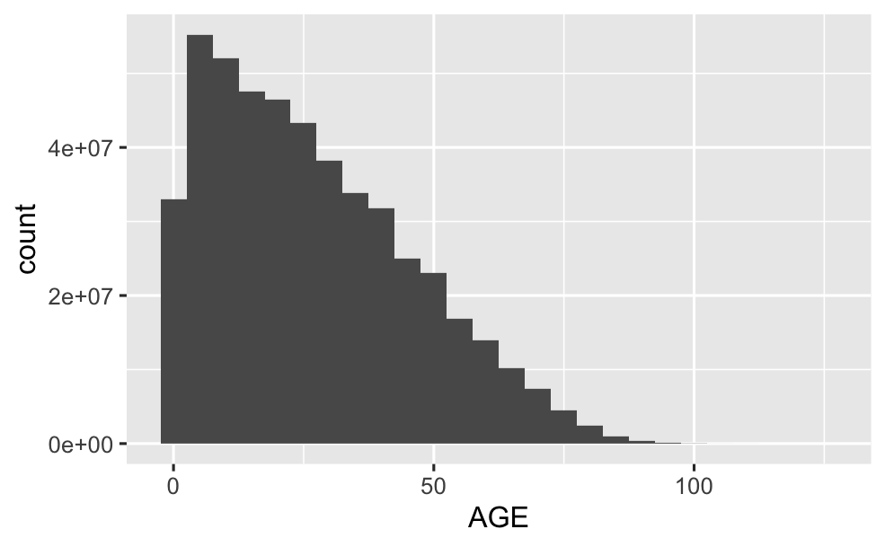

```r
agehist
```

If we want to facet by `SEX` as well as `YEAR`, we can put both variables in the `facet_grid()` layer. We can add this to our `agehist` object.

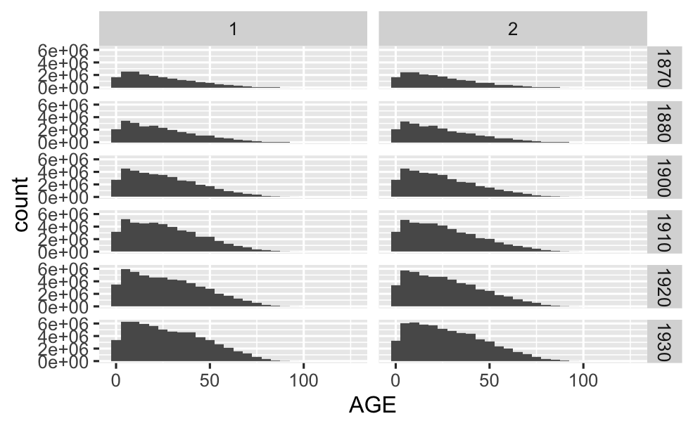

```r
agehist + facet_grid(rows = vars(YEAR), cols = vars(SEX))
```

We can factor `SEX` right in the `facet_grid()` function to get better labels for our plot.

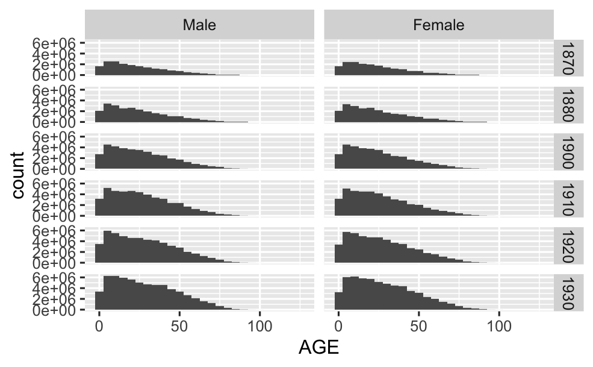

```r
agehist + facet_grid(rows = vars(YEAR), cols = vars(factor(SEX, labels=c("Male","Female"))))
```

Let’s save a smaller plot that we can keep working with: a histogram of `AGE` in 1880 only, faceted horizontally by `SEX`.

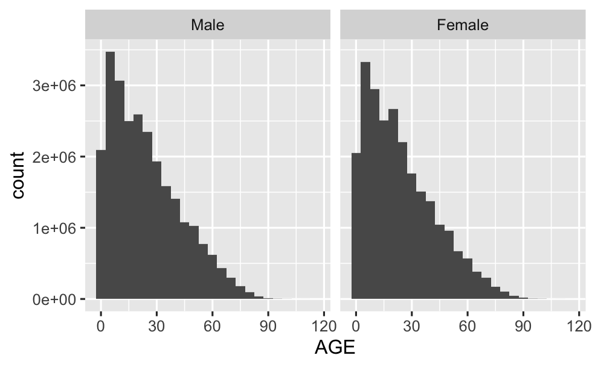

```r
age_1880 <- ipums %>% filter (YEAR == 1880) %>%
  ggplot (aes(AGE,weight = PERWT)) +
  geom_histogram(binwidth = 5) +
  facet_grid(cols=vars(factor(SEX,label=c("Male", "Female"))))
age_1880
```

There is still a lot we can do to make our plot more readable and attractive. We do this by adding more layers. We can change the overall look of our plot with a `theme()` function.

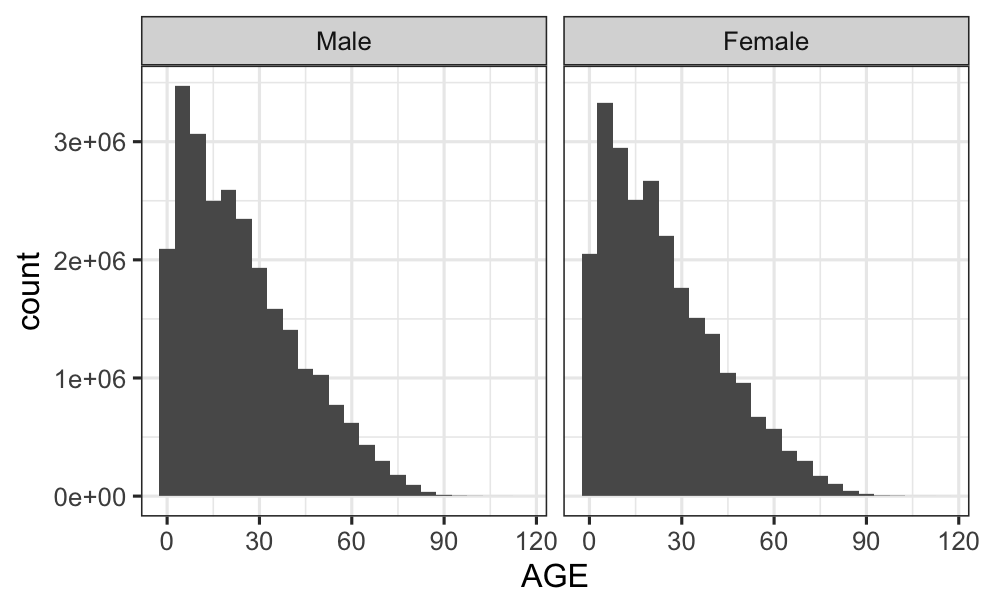

```r
age_1880 + theme_bw()
```

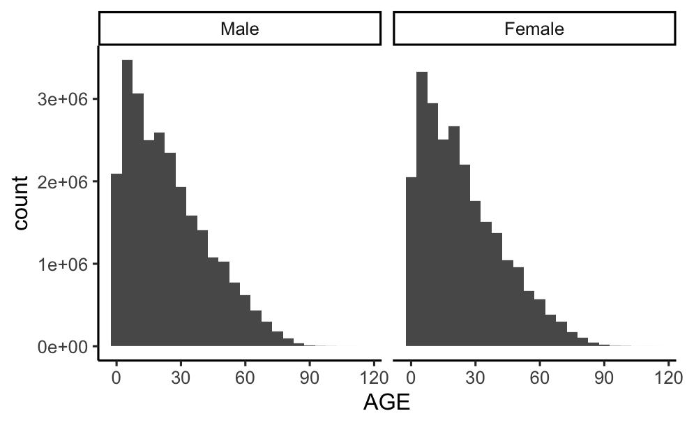

```r
age_1880 + theme_classic()
```

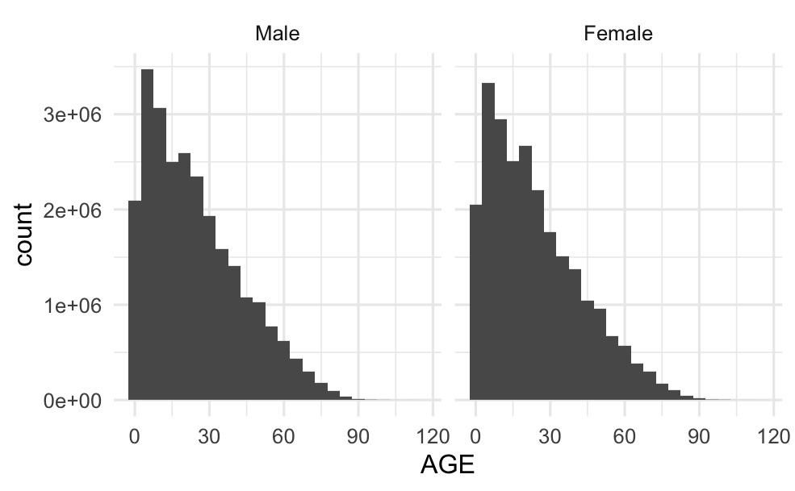

```r
age_1880 + theme_minimal()
```

We can control various aspects of our axes. Here we use the `scale_x_continuous()` function to control the minimum and maximum values of the x-axis and to indicate which values we want to show on that axis, and we use the `scale_y_continuous()` function to format the numbers in the y-axis.

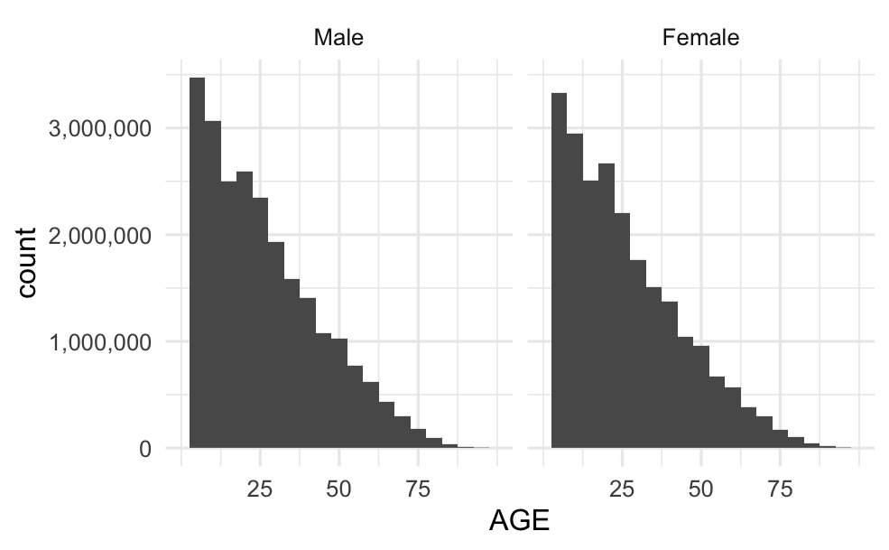

```r
age_1880 + theme_minimal() +
  scale_x_continuous(lim = c(0,100), breaks = c(25, 50, 75)) +
  scale_y_continuous(label = scales::comma)
```

We can use the `labs()` function to change our axis labels and add a title.

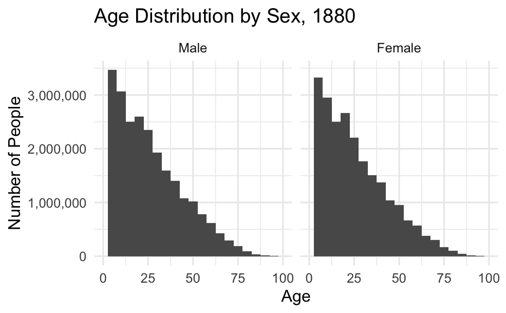

```r
age_1880 + theme_minimal() +
  scale_x_continuous(lim = c(0,100)) +
  scale_y_continuous(label = scales::comma) +
  labs(x = "Age", y = "Number of People", title = "Age Distribution by Sex, 1880")
```

## Adding color

There are other ways to visualize the age distribution over time. We could make a bar graph with `YEAR` on the x-axis and total number of people on the y-axis, with the color of the bars representing people of each age. We will get there step by step.

What is the difference between these two plots?

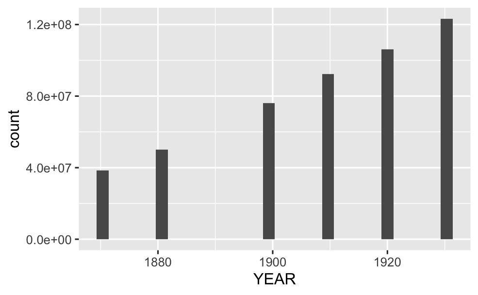

```r
ggplot(ipums, aes(YEAR, weight = PERWT)) + geom_histogram()
```

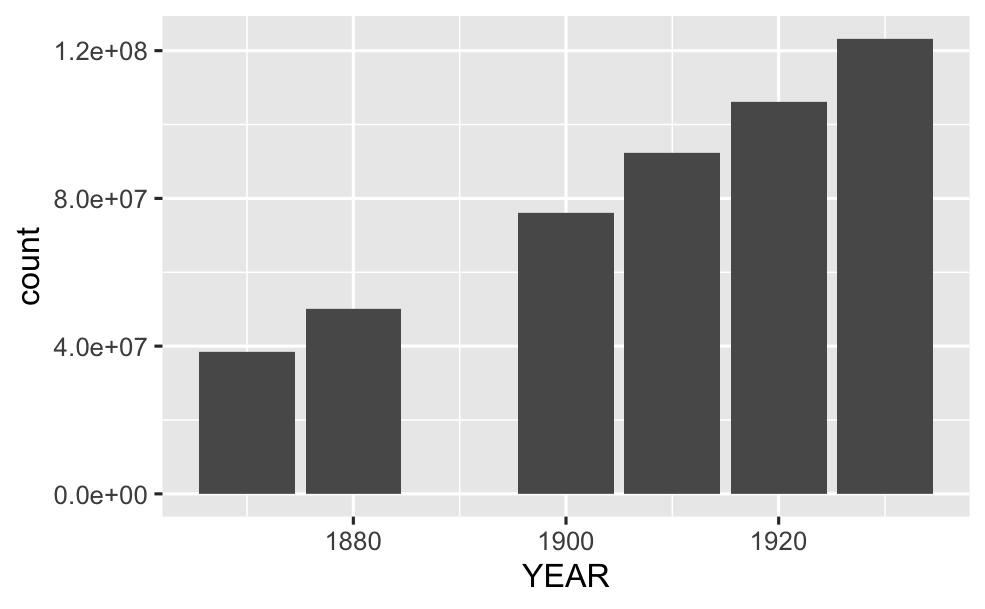

```r
ggplot(ipums, aes(YEAR, weight = PERWT)) + geom_bar()
```

With `ggplot(ipums, aes(YEAR, weight = PERWT)) + geom_bar()`, we fed our whole `ipums` data frame into `ggplot()` and let `ggplot()` calculate the number of people, weighting by `PERWT`. Alternatively, we could have done that ourselves in a previous step, using two new `dplyr` functions: `group_by()` and `count()`.

```r
ipums %>% group_by(YEAR) %>% count(wt = PERWT)
```

| YEAR | n |
| --- | --- |
| 1870 | 38407971 |
| 1880 | 50152560 |
| 1900 | 76069540 |
| 1910 | 92280583 |
| 1920 | 106020331 |
| 1930 | 123242841 |

This command says, for the `ipums` data frame, for each unique value of `YEAR`, count the number of records, weighting by `PERWT`. In the resulting data frame, `n` refers to the number of people in each given year. We can pipe this right into `ggplot()` or we can save it as a new data frame and then put it into `ggplot()`.

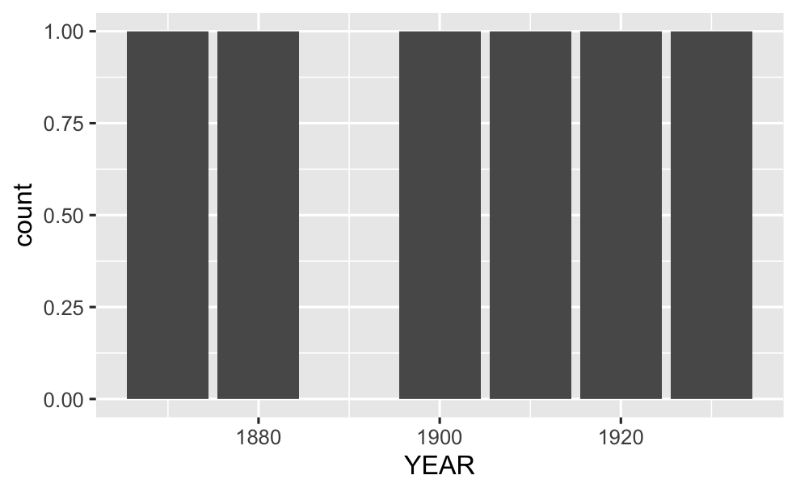

```r
ipums %>% group_by(YEAR) %>% count(wt = PERWT) %>%
  ggplot(aes(YEAR)) + geom_bar()
```

This is not what we were expecting! The `geom_bar()` function counts the number of records for each year in the data frame, which in this case is 1. Instead, we want to use the `geom_col()` function, which lets us specify a variable for the y-axis.

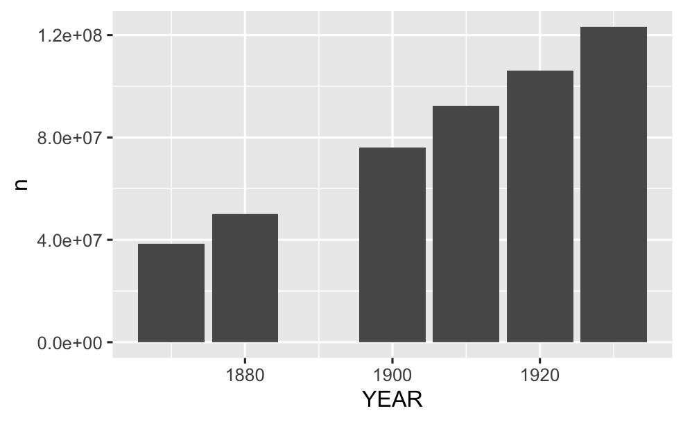

```r
ipums %>% group_by(YEAR) %>% count(wt = PERWT) %>%
  ggplot(aes(YEAR, n)) + geom_col()
```

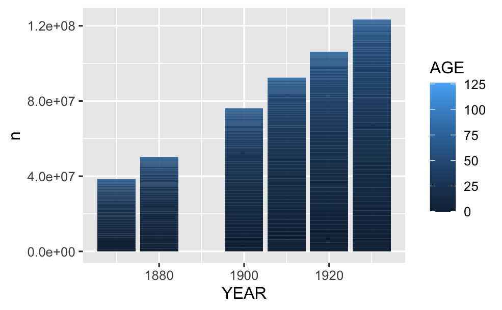

```r
ipums %>% group_by(YEAR, AGE) %>% count(wt = PERWT) %>%
  ggplot(aes(YEAR, n, fill = AGE)) + geom_col()
```

We can add all of our other layers to make the plot look good.

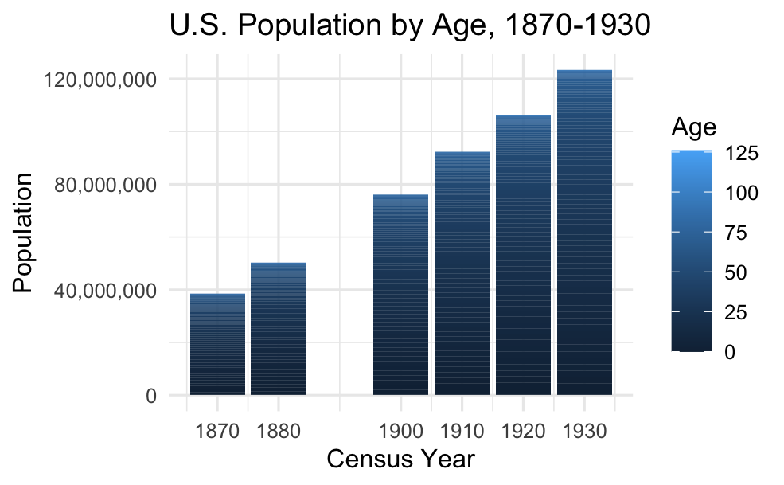

```r
ipums %>% group_by(YEAR, AGE) %>% count(wt = PERWT) %>%
  ggplot(aes(YEAR, n, fill = AGE)) + geom_col() +
    scale_x_continuous(breaks = c(1870, 1880, 1900, 1910, 1920, 1930)) +
    scale_y_continuous(labels = scales::comma) +
    theme_minimal() +
    labs(x = "Census Year", y = "Population", fill = "Age", title = "U.S. Population by Age, 1870-1930")
```

If we want to facet by sex, we will need to make a data frame that includes one row for each combination of `YEAR`, `AGE`, and `SEX`. We can do this by adding `SEX` to the `group_by()` function. Then we just add a `facet_grid()` layer to the `ggplot()` function. Paste in the code from the graph above and make those changes. Be sure to include the value labels for `SEX`.

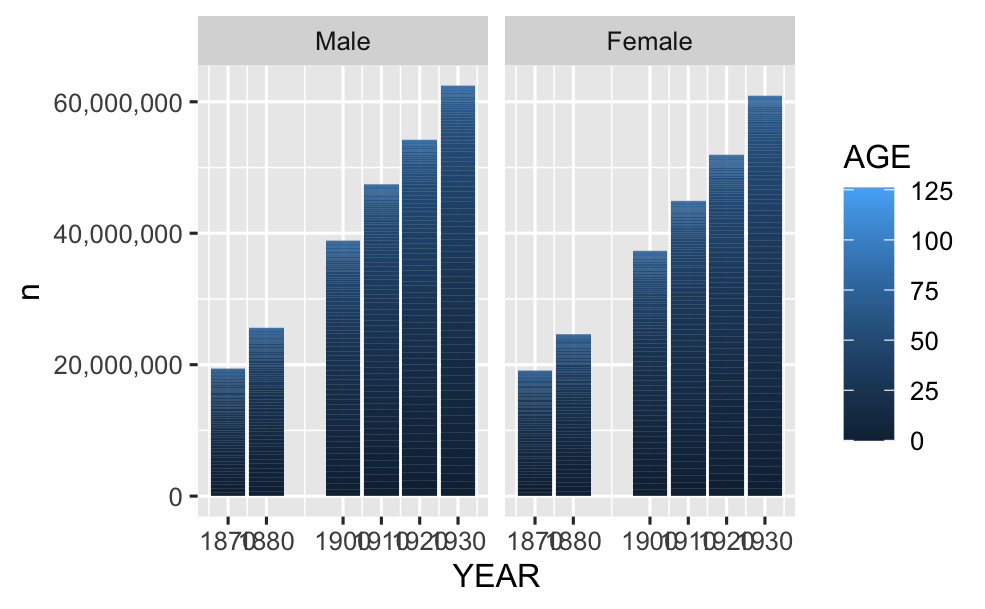

```r
ipums %>% group_by(YEAR, AGE, SEX) %>% count(wt = PERWT) %>%
  ggplot(aes(YEAR, n, fill = AGE)) + geom_col() +
    scale_x_continuous(breaks = c(1870, 1880, 1900, 1910, 1920, 1930)) +
    scale_y_continuous(labels = scales::comma) +
     facet_grid(cols=vars(factor(SEX,label=c("Male", "Female"))))
```

```r
    theme_minimal() +
    labs(x = "Census Year", y = "Population", fill = "Age", title = "U.S. Population by Age, 1870-1930")
```

[output not shown]

[output cut: 332 more lines]

[output not shown]

## Recoding Industry

Let’s do the same thing, but with `IND1950` instead of `AGE`.

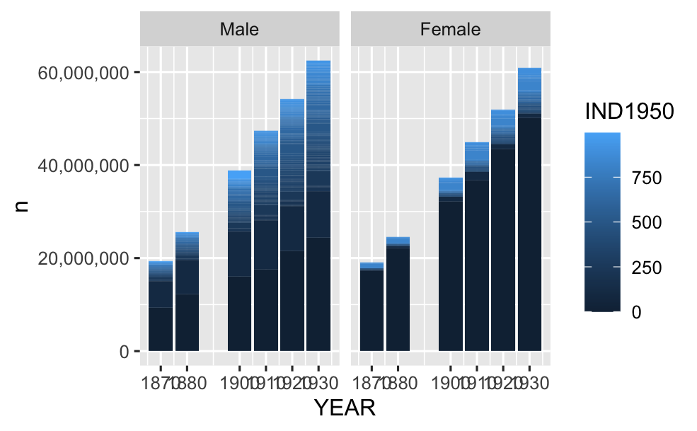

```r
ipums %>% group_by(YEAR, IND1950, SEX) %>% count(wt = PERWT) %>%
  ggplot(aes(YEAR, n, fill = IND1950)) + geom_col() +
    scale_x_continuous(breaks = c(1870, 1880, 1900, 1910, 1920, 1930)) +
    scale_y_continuous(labels = scales::comma) +
     facet_grid(cols=vars(factor(SEX,label=c("Male", "Female"))))
```

```r
    theme_minimal() +
    labs(x = "Census Year", y = "Population", fill = "Age", title = "U.S. Population by Age, 1870-1930")
```

[output not shown]

[output cut: 332 more lines]

[output not shown]

This plot of IND1950 is not very informative. It made sense to plot `AGE` on a continuous color scale because age is a numeric variable, but industry is a categorical variable. `IND1950` has too many values to make sense of individually, so let’s group them together into categories. Look at the documentation for `IND1950` to see how I chose these categories. This recoding process is very similar to the process we used last week to recode `RACE` and `RACED`, but there we were doing a one-to-one recode (one value of the old variable converted to each value of the new variable) and here we are doing a many-to-one recode (many values of the old variable convert to each value of the new variable). For that reason, it is easier to do the recode in two steps: the first step supplies the new numeric values and the second converts it to a factor and adds labels.

```r
ipums <- ipums %>%
          mutate(IND = ifelse(IND1950 == 0 | IND1950 >=979, 1,
                       ifelse(IND1950 < 246, 2,
                       ifelse(IND1950 %in% c(246, 976), 3,
                       ifelse(IND1950 < 500, 4,
                       ifelse(IND1950 < 600, 5,
                       ifelse(IND1950 < 700, 6,
                       ifelse(IND1950 < 800, 7,
                       ifelse(IND1950 < 900, 8, 9))))))))) %>%
          mutate(IND = factor(IND,
                        labels = c("None", "Ag/Ext", "Const/GenLab", "Manuf",
                                    "Trans/Comm", "Trade", "FIRE", "Services", "PubAdm")))
table(ipums$IND)
```

```
        None       Ag/Ext Const/GenLab        Manuf
     3035624       635470        95686       355962
  Trans/Comm        Trade         FIRE     Services
      138505       212660        35923       295631
      PubAdm
       36034
```

We can check to make sure that our recode worked the way we wanted it to by making a scatterplot of `IND` and `IND1950` to see the relationship between the two. Since we are just checking to make sure the recode worked, we don’t need to facet or weight.

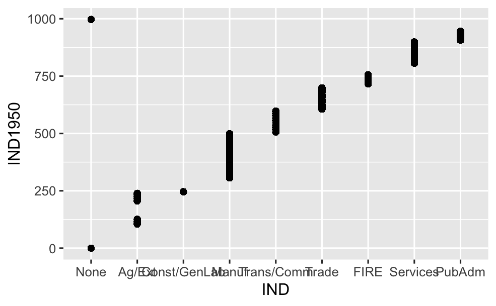

```r
qplot(IND, IND1950, data = ipums)
```

Now we can plot this variable the same way we plotted IND1950 above.

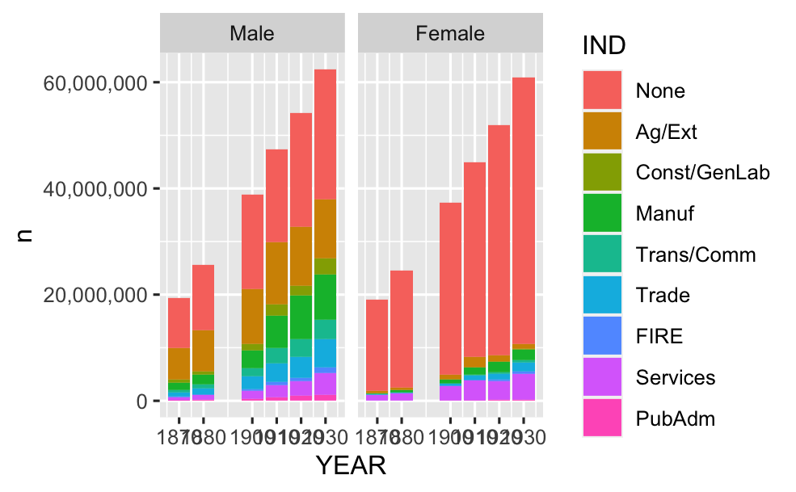

```r
ipums %>% group_by(YEAR, IND, SEX) %>% count(wt = PERWT) %>%
  ggplot(aes(YEAR, n, fill = IND)) + geom_col() +
    scale_x_continuous(breaks = c(1870, 1880, 1900, 1910, 1920, 1930)) +
    scale_y_continuous(labels = scales::comma) +
     facet_grid(cols=vars(factor(SEX,label=c("Male", "Female"))))
```

```r
    theme_minimal() +
    labs(x = "Census Year", y = "Population", fill = "Age", title = "U.S. Population by Age, 1870-1930")
```

[output not shown]

[output cut: 332 more lines]

[output not shown]

## Thinking Spatially

Although railroads were rapidly producing a national economy and national culture, the experience of industrializing America differed strongly by region and by race. Here we will consider region; in the lab we will also consider race. We are going to use the `STATEFIP` variable to assign each record to one of the four [census regions](https://www2.census.gov/geo/docs/maps-data/maps/reg_div.txt): Northeast, Midwest, South, and West. For this analysis, let’s eliminate Alaska, Hawaii, and any records that don’t list one of the other 48 states.

The first thing we will do is make a vector of the `STATEFIP` codes for each region:

```r
northeast <- c(9, 23, 25, 33, 44, 50, 34, 36, 42)
midwest <- c(17, 18, 26, 39, 55, 19, 20, 27, 29, 31, 38, 46)
south <- c(10, 11, 12, 13, 24, 37, 45, 51, 54, 1, 21, 28, 47, 5, 22, 40, 48)
west <- c(4, 8, 16, 30, 32, 35, 49, 56, 6, 41, 53)
```

Now we can use these vectors to create a new variable called `REGION`:

```r
ipums <- ipums %>% mutate(REGION = ifelse(STATEFIP %in% northeast, 1,
                                   ifelse(STATEFIP %in% midwest, 2,
                                   ifelse(STATEFIP %in% south, 3,
                                   ifelse(STATEFIP %in% west, 4, 0))))) %>%
  filter(REGION>0) %>%
  mutate(REGION = factor(REGION, labels=c("Northeast", "Midwest", "South", "West")))
table(ipums$REGION)
```

```
Northeast   Midwest     South      West
  1363177   1586485   1533707    344559
```

For this week, we will focus our analysis on men aged 15-64. Create a new data frame that only includes these men, and that contains all of the variables we have made so far. Test to make sure you have done this correctly.

```r
men <- ipums %>% filter(SEX==1 & AGE %in% 15:64)
table(men$SEX)
```

```
      1
1545977
```

```r
summary(men$AGE)
```

```
   Min. 1st Qu.  Median    Mean 3rd Qu.    Max.
  15.00   23.00   32.00   34.29   44.00   64.00
```

```r
names(men)
```

```
 [1] "YEAR"     "STATEFIP" "PERWT"    "SEX"      "AGE"
 [6] "RACE"     "RACED"    "OCC"      "OCC1950"  "IND1950"
[11] "IND"      "REGION"
```

Now make a plot with `YEAR` on the x-axis, number of people on the y-axis, and `IND` represented by fill, with facets for `REGION`. By default, `ggplot()` uses the same scales on the x- and y-axes for all facets. This enhances comparability, but in this case makes it difficult to see what is going on in the West. We can allow different y-axis scales in each facet by including the `scales = "free_y"` argument in the `facet_wrap()` function. Note that I have made the height of the graph taller with `fig.height = 10` in the curly braces that start the code block.

```r
men %>% group_by(YEAR,IND,REGION) %>% count(wt = PERWT) %>%
ggplot(aes(YEAR,n,fill=IND)) + geom_col() +
facet_wrap(vars(REGION),scales="free_y")+
scale_x_continuous(breaks=c(1870,1880,1900,1910,1920,1930))+
    scale_y_continuous(labels=scales::comma)+
  theme_minimal()+
    labs(x="Census Year", y="Number of Men 15-64", fill = "Industry", title="Industry by Region for Men Aged 15-64, 1870-1930")
```

[figure not shown]